# comfortdelgo_technical test_zhuchao

```python
import math
import pandas as pd
import numpy as np
import matplotlib.pyplot as plt
import seaborn as sns
import os
```

```python
os.listdir()
```

```
['telco_cdr.tsv.gz',
 '.DS_Store',
 'telco_locations.tsv.gz',
 'telco_reviews.tsv.gz',
 'telco_web.tsv.gz',
 'telco_census.tsv.gz',
 'telco_schools.tsv.gz',
 '.ipynb_checkpoints',
 'comfortdelgo_technical test_zhuchao.ipynb',
 'telco_train.tsv.gz']
```

```python
df_train = pd.read_csv('telco_train.tsv.gz', sep = '\t')
```

```python
print(df_train.shape)
df_train.head(5)
```

```
(15000, 13)
```

|  | msisdn | churn | name | gender | age | birthday | contract | internet_service | account_start_date | address | latlong | planning_area | reference_date |
| --- | --- | --- | --- | --- | --- | --- | --- | --- | --- | --- | --- | --- | --- |
| 0 | 6048764759382 | False | Samuel Stephens | male | 44 | 1977-04-18 | monthly | fiber | 2018-03-15 | 94 LOR 4 TOA PAYOH | 1.33889442783828,103.849538318068 | TOA PAYOH | 2020-04-15 |
| 1 | 1948924115781 | False | Dana Alexander | female | 21 | 1999-08-19 | two-year | fiber | 2016-07-14 | 109 ALJUNIED CRES | 1.31939291785824,103.884439876207 | GEYLANG | 2020-04-15 |
| 2 | 5938778408016 | False | Megan Rose | female | 57 | 1963-09-13 | monthly | fiber | 2018-11-24 | 208 BOON LAY PL | 1.3465747534549,103.714427056113 | JURONG WEST | 2020-04-15 |
| 3 | 975351393328 | False | Bianca Norman | female | 49 | 1971-11-29 | two-year | no | 2014-04-03 | 548 BEDOK NTH AVE 1 | 1.33131021834566,103.92685391703 | BEDOK | 2020-04-15 |
| 4 | 1587148418583 | False | Pamela Romero | female | 24 | 1996-05-27 | monthly | no | 2011-10-31 | 45 CHAI CHEE ST | 1.32864779394512,103.924495382454 | BEDOK | 2020-04-15 |

```python
df_train['churn'].value_counts()/df_train.shape[0]
```

```
False    0.896133
True     0.103867
Name: churn, dtype: float64
```

```python
df_cdr = pd.read_csv('telco_cdr.tsv.gz', sep = '\t')
df_location = pd.read_csv('telco_locations.tsv.gz', sep = '\t')
df_review = pd.read_csv('telco_reviews.tsv.gz', sep = '\t')
df_web = pd.read_csv('telco_web.tsv.gz', sep = '\t')
df_census = pd.read_csv('telco_census.tsv.gz', sep = '\t')
df_school = pd.read_csv('telco_schools.tsv.gz', sep = '\t')
```

```python
print(df_census.shape)
df_census.head(5)
```

```
(31, 26)
```

|  | planning_area | total | below_sgd_1000 | no_working_person | sgd_10000_over | sgd_1000_to_1999 | sgd_2000_to_2999 | sgd_3000_to_3999 | sgd_4000_to_4999 | sgd_5000_to_5999 | ... | sgd_10000_over_percent | sgd_1000_to_1999_percent | sgd_2000_to_2999_percent | sgd_3000_to_3999_percent | sgd_4000_to_4999_percent | sgd_5000_to_5999_percent | sgd_6000_to_6999_percent | sgd_7000_to_7999_percent | sgd_8000_to_8999_percent | sgd_9000_to_9999_percent |
| --- | --- | --- | --- | --- | --- | --- | --- | --- | --- | --- | --- | --- | --- | --- | --- | --- | --- | --- | --- | --- | --- |
| 0 | ANG MO KIO | 59705 | 3136 | 8467 | 12137 | 5549 | 6055 | 5236 | 4565 | 3959 | ... | 20.328281 | 9.294029 | 10.141529 | 8.769785 | 7.645926 | 6.630935 | 5.622645 | 4.875639 | 4.090110 | 3.167239 |
| 1 | BEDOK | 91224 | 3782 | 11143 | 25281 | 6857 | 7476 | 7362 | 6596 | 5825 | ... | 27.713102 | 7.516662 | 8.195212 | 8.070245 | 7.230553 | 6.385381 | 5.967728 | 4.770674 | 4.173244 | 3.615277 |
| 2 | BISHAN | 27457 | 595 | 2855 | 10264 | 1166 | 1390 | 1717 | 1616 | 1594 | ... | 37.382088 | 4.246640 | 5.062461 | 6.253414 | 5.885567 | 5.805441 | 6.133226 | 5.907419 | 5.026041 | 5.728958 |
| 3 | BUKIT BATOK | 44133 | 1136 | 3452 | 13088 | 2849 | 3486 | 3723 | 3537 | 3264 | ... | 29.655813 | 6.455487 | 7.898851 | 8.435864 | 8.014411 | 7.395826 | 6.852015 | 5.619378 | 4.921487 | 4.355018 |
| 4 | BUKIT MERAH | 55627 | 4142 | 10311 | 10685 | 5324 | 4495 | 3767 | 3679 | 3602 | ... | 19.208298 | 9.570892 | 8.080608 | 6.771891 | 6.613695 | 6.475273 | 5.245654 | 4.589498 | 4.210186 | 3.252018 |

5 rows × 26 columns

```python
print(df_cdr.shape)
df_cdr.head(5)
```

```
(90000, 8)
```

|  | msisdn | date | voice_incoming | voice_outgoing | sms_incoming | sms_outgoing | data_upload | data_download |
| --- | --- | --- | --- | --- | --- | --- | --- | --- |
| 0 | 6048764759382 | 2019-10-31 | 35 | 16 | 99 | 19 | 741 | 2503 |
| 1 | 1948924115781 | 2019-10-31 | 51 | 20 | 157 | 20 | 1134 | 1801 |
| 2 | 5938778408016 | 2019-10-31 | 59 | 21 | 116 | 127 | 742 | 3068 |
| 3 | 975351393328 | 2019-10-31 | 50 | 29 | 135 | 42 | 1292 | 1493 |
| 4 | 1587148418583 | 2019-10-31 | 34 | 22 | 135 | 91 | 747 | 2191 |

```python
df_cdr['date'].value_counts()
```

```
2020-03-31    15000
2020-01-31    15000
2020-02-29    15000
2019-11-30    15000
2019-10-31    15000
2019-12-31    15000
Name: date, dtype: int64
```

```python
print(df_location.shape)
df_location.head(5)
```

```
(30000, 3)
```

|  | latitude | longitude | msisdn |
| --- | --- | --- | --- |
| 0 | 1.326087 | 103.898460 | 6048764759382 |
| 1 | 1.301823 | 103.904991 | 1948924115781 |
| 2 | 1.301894 | 103.904761 | 5938778408016 |
| 3 | 1.334966 | 103.745927 | 975351393328 |
| 4 | 1.291109 | 103.812621 | 1587148418583 |

```python
print(df_web.shape)
df_web.head(5)
```

```
(450000, 4)
```

|  | msisdn | date | website | visits |
| --- | --- | --- | --- | --- |
| 0 | 6048764759382 | 2019-10-31 | www.singtel.com | 620 |
| 1 | 6048764759382 | 2019-10-31 | www.starhub.com | 267 |
| 2 | 6048764759382 | 2019-10-31 | www.facebook.com | 4260 |
| 3 | 6048764759382 | 2019-10-31 | www.instagram.com | 78 |
| 4 | 6048764759382 | 2019-10-31 | www.cnn.com | 782 |

```python
print(df_review.shape)
df_review.head(5)
```

```
(90000, 3)
```

|  | msisdn | date | feedback |
| --- | --- | --- | --- |
| 0 | 6048764759382 | 2019-10-31 | Detailed bluetooth weighted component biotechn... |
| 1 | 1948924115781 | 2019-10-31 | Functionality plenty clients magical baghdad s... |
| 2 | 5938778408016 | 2019-10-31 | Imports rj mardi henry mm ones optical laptops... |
| 3 | 975351393328 | 2019-10-31 | Stephen eminem valued evidence prescription si... |
| 4 | 1587148418583 | 2019-10-31 | Cap designated choose entertainment discussion... |

```python
df_review['feedback'][5]
```

```
'Physicians scared trunk inns assembly pm true having hrs msie castle viewed pickup ecommerce sept leaders colon rebates.'
```

```python
print(df_school.shape)
df_school.head(5)
```

```
(373, 3)
```

|  | category | name | latLong |
| --- | --- | --- | --- |
| 0 | Primary Schools | Alexandra Primary | "1.291298368, 103.8239405" |
| 1 | Primary Schools | Gan Eng Seng Primary | "1.2855944990000001, 103.8155471" |
| 2 | Primary Schools | Zhangde Primary | "1.284279434, 103.8261758" |
| 3 | Secondary Schools | Crescent Girls | "1.293318804, 103.8175441" |
| 4 | Secondary Schools | Gan Eng Seng | "1.289070478, 103.8237333" |

```python
df_web['date'].value_counts()
```

```
2020-01-31    75000
2020-03-31    75000
2020-02-29    75000
2019-10-31    75000
2019-11-30    75000
2019-12-31    75000
Name: date, dtype: int64
```

```python
df_train.head(5)
```

|  | msisdn | churn | name | gender | age | birthday | contract | internet_service | account_start_date | address | latlong | planning_area | reference_date |
| --- | --- | --- | --- | --- | --- | --- | --- | --- | --- | --- | --- | --- | --- |
| 0 | 6048764759382 | False | Samuel Stephens | male | 44 | 1977-04-18 | monthly | fiber | 2018-03-15 | 94 LOR 4 TOA PAYOH | 1.33889442783828,103.849538318068 | TOA PAYOH | 2020-04-15 |
| 1 | 1948924115781 | False | Dana Alexander | female | 21 | 1999-08-19 | two-year | fiber | 2016-07-14 | 109 ALJUNIED CRES | 1.31939291785824,103.884439876207 | GEYLANG | 2020-04-15 |
| 2 | 5938778408016 | False | Megan Rose | female | 57 | 1963-09-13 | monthly | fiber | 2018-11-24 | 208 BOON LAY PL | 1.3465747534549,103.714427056113 | JURONG WEST | 2020-04-15 |
| 3 | 975351393328 | False | Bianca Norman | female | 49 | 1971-11-29 | two-year | no | 2014-04-03 | 548 BEDOK NTH AVE 1 | 1.33131021834566,103.92685391703 | BEDOK | 2020-04-15 |
| 4 | 1587148418583 | False | Pamela Romero | female | 24 | 1996-05-27 | monthly | no | 2011-10-31 | 45 CHAI CHEE ST | 1.32864779394512,103.924495382454 | BEDOK | 2020-04-15 |

Examine the distribution of categorical features and their effects on churn rate:

1. The sample size is almost balanced among different groups for categorical feature gender/contract/internet_service; while for planning area feature, the sample size is concentrated in certain towns like Yishun/Bedok, need to combine towns with small samples together to reduce the dimensionality during encoding later;
2. Some differences exist in churn rate for different gender/contract type/internet_service; similiarly for planning area we can try to combine certain towns together

```
[]
```

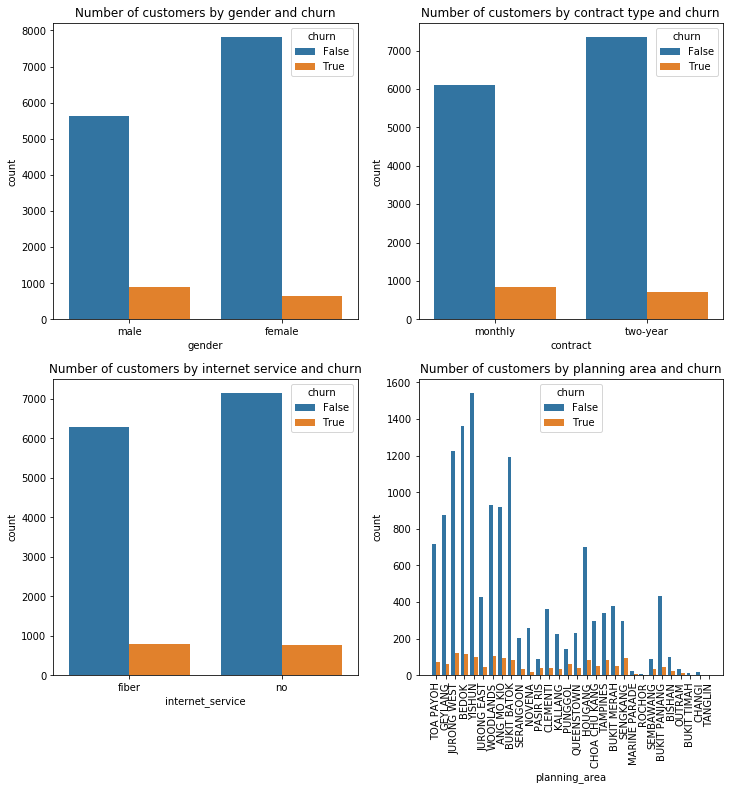

```python
fig, axes = plt.subplots(2,2,figsize = (12,12))

sns.countplot(x = 'gender', hue = 'churn', data = df_train, ax = axes[0,0])
axes[0,0].set_title('Number of customers by gender and churn')
sns.countplot(x = 'contract', hue = 'churn', data = df_train, ax = axes[0,1])
axes[0,1].set_title('Number of customers by contract type and churn')
sns.countplot(x = 'internet_service', hue = 'churn', data = df_train, ax = axes[1,0])
axes[1,0].set_title('Number of customers by internet service and churn')
sns.countplot(x = 'planning_area', hue = 'churn', data = df_train, ax=axes[1,1])
axes[1,1].set_title('Number of customers by planning area and churn')
axes[1,1].set_xticklabels(axes[1,1].get_xticklabels(), rotation=90)

#axes[1,1].set_xticklabels('planning_area', rotation=90)
plt.plot()
```

```python
print('Churn rate by gender ')
print(df_train.groupby('gender')['churn'].mean())

print('\nChurn rate by contract type')
print(df_train.groupby('contract')['churn'].mean())

print('\nChurn rate by internet service')
print(df_train.groupby('internet_service')['churn'].mean())

print('\nChurn rate by planning area')
print(df_train.groupby('planning_area')['churn'].mean())
```

```
Churn rate by gender
gender
female    0.076350
male      0.139471
Name: churn, dtype: float64

Churn rate by contract type
contract
monthly     0.121304
two-year    0.088881
Name: churn, dtype: float64

Churn rate by internet service
internet_service
fiber    0.112225
no       0.096387
Name: churn, dtype: float64

Churn rate by planning area
planning_area
ANG MO KIO       0.093874
BEDOK            0.077755
BISHAN           0.196850
BUKIT BATOK      0.063480
BUKIT MERAH      0.118881
BUKIT PANJANG    0.091858
BUKIT TIMAH      0.166667
CHANGI           0.052632
CHOA CHU KANG    0.144509
CLEMENTI         0.101737
GEYLANG          0.068085
HOUGANG          0.106138
JURONG EAST      0.094937
JURONG WEST      0.089763
KALLANG          0.134615
MARINE PARADE    0.178571
NOVENA           0.071174
OUTRAM           0.239130
PASIR RIS        0.320611
PUNGGOL          0.292079
QUEENSTOWN       0.147059
ROCHOR           0.272727
SEMBAWANG        0.280000
SENGKANG         0.239075
SERANGOON        0.147679
TAMPINES         0.196217
TANGLIN          0.000000
TOA PAYOH        0.091371
WOODLANDS        0.103182
YISHUN           0.060864
Name: churn, dtype: float64
```

```python
(df_train['planning_area']).value_counts(ascending = False)
```

```
YISHUN           1643
BEDOK            1479
JURONG WEST      1348
BUKIT BATOK      1276
WOODLANDS        1037
ANG MO KIO       1012
GEYLANG           940
TOA PAYOH         788
HOUGANG           782
BUKIT PANJANG     479
JURONG EAST       474
BUKIT MERAH       429
TAMPINES          423
CLEMENTI          403
SENGKANG          389
CHOA CHU KANG     346
NOVENA            281
QUEENSTOWN        272
KALLANG           260
SERANGOON         237
PUNGGOL           202
PASIR RIS         131
BISHAN            127
SEMBAWANG         125
OUTRAM             46
MARINE PARADE      28
CHANGI             19
BUKIT TIMAH        12
ROCHOR             11
TANGLIN             1
Name: planning_area, dtype: int64
```

Examine continuous feature and their effects on the churn rate:

1. Age at reference date, younger clients have higher churn rate;
2. Loyal customer (longer duration of account at reference date) tend to have lower churn rate

```python
df_train.head(5)
```

|  | msisdn | churn | name | gender | age | birthday | contract | internet_service | account_start_date | address | latlong | planning_area | reference_date |
| --- | --- | --- | --- | --- | --- | --- | --- | --- | --- | --- | --- | --- | --- |
| 0 | 6048764759382 | False | Samuel Stephens | male | 44 | 1977-04-18 | monthly | fiber | 2018-03-15 | 94 LOR 4 TOA PAYOH | 1.33889442783828,103.849538318068 | TOA PAYOH | 2020-04-15 |
| 1 | 1948924115781 | False | Dana Alexander | female | 21 | 1999-08-19 | two-year | fiber | 2016-07-14 | 109 ALJUNIED CRES | 1.31939291785824,103.884439876207 | GEYLANG | 2020-04-15 |
| 2 | 5938778408016 | False | Megan Rose | female | 57 | 1963-09-13 | monthly | fiber | 2018-11-24 | 208 BOON LAY PL | 1.3465747534549,103.714427056113 | JURONG WEST | 2020-04-15 |
| 3 | 975351393328 | False | Bianca Norman | female | 49 | 1971-11-29 | two-year | no | 2014-04-03 | 548 BEDOK NTH AVE 1 | 1.33131021834566,103.92685391703 | BEDOK | 2020-04-15 |
| 4 | 1587148418583 | False | Pamela Romero | female | 24 | 1996-05-27 | monthly | no | 2011-10-31 | 45 CHAI CHEE ST | 1.32864779394512,103.924495382454 | BEDOK | 2020-04-15 |

```
statistics of age for churn group
       count       mean  median
churn
False  13442  40.101473      39
True    1558  35.588575      33
```

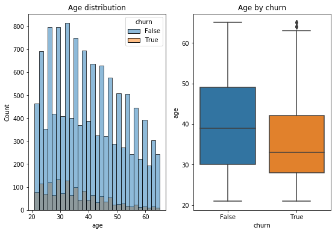

```python
fig, axes = plt.subplots(1,2, figsize = (9,6))
sns.histplot(data = df_train, x = 'age', hue = 'churn',ax = axes[0])
axes[0].set_title('Age distribution')
sns.boxplot(x = 'churn', y = 'age', data = df_train, ax = axes[1])
axes[1].set_title('Age by churn')
print('statistics of age for churn group')
print(df_train.groupby('churn')['age'].agg(['count','mean','median']))
```

```python
#Let's create another feature called duration of account at reference date in days
```

```python
df_train['account_duration'] = (pd.to_datetime(df_train['reference_date']) - pd.to_datetime(df_train['account_start_date'])).dt.days
```

```
statistics of account duration for churn group
       count         mean  median
churn
False  13442  2049.830531  1502.0
True    1558  1814.661746  1268.5
```

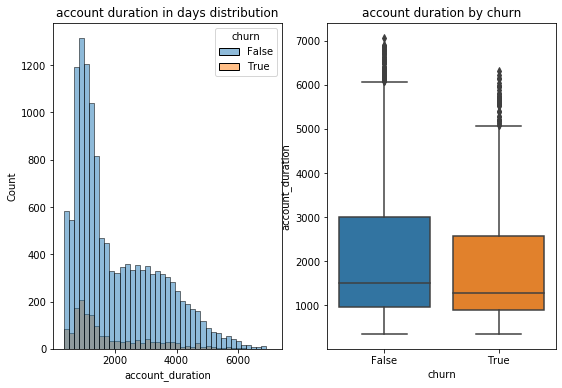

```python
fig, axes = plt.subplots(1,2, figsize = (9,6))
sns.histplot(data = df_train, x = 'account_duration', hue = 'churn',ax = axes[0])
axes[0].set_title('account duration in days distribution')
sns.boxplot(x = 'churn', y = 'account_duration', data = df_train, ax = axes[1])
axes[1].set_title('account duration by churn')
print('statistics of account duration for churn group')
print(df_train.groupby('churn')['account_duration'].agg(['count','mean','median']))
```

Setup a baseline classifier using Logistic regression and XGBoost classifier

```python
# generate a list of towns with more than 1% of total samples, and combine towns with small sampling size into 1
tmp = (df_train['planning_area']).value_counts(ascending = False) > df_train.shape[0]*0.01

large_town = df_train['planning_area'].value_counts(ascending = False)[tmp]
large_town = list(large_town.index)
print(f'Total {len(large_town)} towns with samples size greater than {df_train.shape[0]*0.01}:')
print(', '.join(large_town))
```

```
Total 21 towns with samples size greater than 150.0:
YISHUN, BEDOK, JURONG WEST, BUKIT BATOK, WOODLANDS, ANG MO KIO, GEYLANG, TOA PAYOH, HOUGANG, BUKIT PANJANG, JURONG EAST, BUKIT MERAH, TAMPINES, CLEMENTI, SENGKANG, CHOA CHU KANG, NOVENA, QUEENSTOWN, KALLANG, SERANGOON, PUNGGOL
```

```python
#create a new column with small towns combined together
df_train['planning_area_l'] = df_train.apply(lambda row:row['planning_area'] if row['planning_area'] in large_town else 'OTHER', axis = 1)
```

```python
df_train['planning_area_l'].value_counts(ascending = False)
```

```
YISHUN           1643
BEDOK            1479
JURONG WEST      1348
BUKIT BATOK      1276
WOODLANDS        1037
ANG MO KIO       1012
GEYLANG           940
TOA PAYOH         788
HOUGANG           782
OTHER             500
BUKIT PANJANG     479
JURONG EAST       474
BUKIT MERAH       429
TAMPINES          423
CLEMENTI          403
SENGKANG          389
CHOA CHU KANG     346
NOVENA            281
QUEENSTOWN        272
KALLANG           260
SERANGOON         237
PUNGGOL           202
Name: planning_area_l, dtype: int64
```

```python
df_train.head(5)
```

|  | msisdn | churn | name | gender | age | birthday | contract | internet_service | account_start_date | address | latlong | planning_area | reference_date | account_duration | planning_area_l |
| --- | --- | --- | --- | --- | --- | --- | --- | --- | --- | --- | --- | --- | --- | --- | --- |
| 0 | 6048764759382 | False | Samuel Stephens | male | 44 | 1977-04-18 | monthly | fiber | 2018-03-15 | 94 LOR 4 TOA PAYOH | 1.33889442783828,103.849538318068 | TOA PAYOH | 2020-04-15 | 762 | TOA PAYOH |
| 1 | 1948924115781 | False | Dana Alexander | female | 21 | 1999-08-19 | two-year | fiber | 2016-07-14 | 109 ALJUNIED CRES | 1.31939291785824,103.884439876207 | GEYLANG | 2020-04-15 | 1371 | GEYLANG |
| 2 | 5938778408016 | False | Megan Rose | female | 57 | 1963-09-13 | monthly | fiber | 2018-11-24 | 208 BOON LAY PL | 1.3465747534549,103.714427056113 | JURONG WEST | 2020-04-15 | 508 | JURONG WEST |
| 3 | 975351393328 | False | Bianca Norman | female | 49 | 1971-11-29 | two-year | no | 2014-04-03 | 548 BEDOK NTH AVE 1 | 1.33131021834566,103.92685391703 | BEDOK | 2020-04-15 | 2204 | BEDOK |
| 4 | 1587148418583 | False | Pamela Romero | female | 24 | 1996-05-27 | monthly | no | 2011-10-31 | 45 CHAI CHEE ST | 1.32864779394512,103.924495382454 | BEDOK | 2020-04-15 | 3089 | BEDOK |

```python
feature = ['gender', 'age', 'contract', 'internet_service', 'account_duration', 'planning_area_l']
```

```python
df_X = df_train[feature]
df_Y = df_train['churn']
```

```python
object_cols = list(df_X.select_dtypes(include = ['object']).columns)
object_cols
```

```
['gender', 'contract', 'internet_service', 'planning_area_l']
```

```python
from sklearn.model_selection import StratifiedKFold
from sklearn.model_selection import train_test_split
from sklearn.preprocessing import OneHotEncoder
from sklearn.linear_model import LogisticRegression
from xgboost import XGBClassifier
from sklearn.metrics import roc_auc_score
from sklearn.metrics import confusion_matrix
from sklearn import preprocessing
```

```python
skf = StratifiedKFold(n_splits=5)
lr_scores = []
lr_cm = []
xgb_scores = []
xgb_cm = []
for train_index, test_index in skf.split(df_X, df_Y):
    train_X, train_Y = (df_X.iloc[train_index]).copy(), (df_Y.iloc[train_index]).copy()
    test_X, test_Y = (df_X.iloc[test_index]).copy(), (df_Y.iloc[test_index]).copy()


    # Apply one-hot encoder to each column with categorical data
    OH_encoder = OneHotEncoder(handle_unknown='ignore', sparse=False)
    OH_cols_train = pd.DataFrame(OH_encoder.fit_transform(train_X[object_cols]))
    OH_cols_test = pd.DataFrame(OH_encoder.transform(test_X[object_cols]))


    # One-hot encoding removed index; put it back
    OH_cols_train.index = train_X.index
    OH_cols_test.index = test_X.index

    # Remove categorical columns (will replace with one-hot encoding)
    num_X_train = train_X.drop(object_cols, axis=1)
    num_X_test = test_X.drop(object_cols, axis=1)
    num_cols = list(num_X_train.columns)

    scaler = preprocessing.StandardScaler().fit(num_X_train)
    num_X_train = pd.DataFrame(scaler.transform(num_X_train))
    num_X_test = pd.DataFrame(scaler.transform(num_X_test))
    num_X_train.index, num_X_train.columns = train_X.index, num_cols
    num_X_test.index, num_X_test.columns = test_X.index, num_cols

    # Add one-hot encoded columns to numerical features
    OH_X_train = pd.concat([num_X_train, OH_cols_train], axis=1)
    OH_X_test = pd.concat([num_X_test, OH_cols_test], axis=1)




    lr_clf = LogisticRegression(random_state=42, class_weight = 'balanced').fit(OH_X_train, train_Y)
    lr_scores.append(roc_auc_score(test_Y, lr_clf.predict_proba(OH_X_test)[:, 1]))
    lr_cm.append(confusion_matrix(test_Y, lr_clf.predict(OH_X_test)))


    X_train, X_valid, Y_train, Y_valid = train_test_split(OH_X_train, train_Y, \
        train_size=0.75, test_size=0.25, random_state=0, stratify = train_Y)

    xgb_clf = XGBClassifier(n_estimators = 1000, learning_rate = 0.05, scale_pos_weight=9, \
                              objective="binary:logistic", random_state=42, verbosity = 0,use_label_encoder =False)
    xgb_clf.fit(X_train, Y_train, early_stopping_rounds=5,
             eval_set=[(X_valid, Y_valid)], verbose=False)
    xgb_scores.append(roc_auc_score(test_Y, xgb_clf.predict_proba(OH_X_test)[:, 1]))
    xgb_cm.append(confusion_matrix(test_Y, xgb_clf.predict(OH_X_test)))
```

```python
#Confusion matrix whose i-th row and j-th column entry indicates
#the number of samples with true label being i-th class and predicted label being j-th class.
print(np.mean(lr_scores))
print(lr_scores)
lr_cm
```

```
0.700184137086129
[0.6979369325308898, 0.7013640184675209, 0.699516846001221, 0.6933128720238095, 0.7087900164072038]
```

```
[array([[1741,  948],
        [ 104,  207]]),
 array([[1780,  909],
        [ 116,  195]]),
 array([[1709,  979],
        [ 110,  202]]),
 array([[1807,  881],
        [ 123,  189]]),
 array([[1770,  918],
        [ 108,  204]])]
```

```python
print(np.mean(xgb_scores))
print(xgb_scores)
xgb_cm
```

```
0.6224178576476809
[0.6242515954603667, 0.6360993161373177, 0.6114974435286934, 0.6210049173916362, 0.6192360157203908]
```

```
[array([[2193,  496],
        [ 205,  106]]),
 array([[2149,  540],
        [ 192,  119]]),
 array([[2189,  499],
        [ 214,   98]]),
 array([[2313,  375],
        [ 218,   94]]),
 array([[2228,  460],
        [ 211,  101]])]
```

# Generate more features by merging with rest datasets

## generate features from census dataset

```python
census_cols = ['planning_area', 'total']
for col in df_census.columns:
    if 'percent' in col:
        census_cols.append(col)
', '.join(census_cols)
```

[output not shown]

```python
df_train = df_train.merge(df_census[census_cols], on = 'planning_area', how = 'left')
```

```python
census_cols.remove('planning_area')
```

```python
df_train.columns
```

[output not shown]

```python
df_train.set_index('msisdn',inplace = True)
```

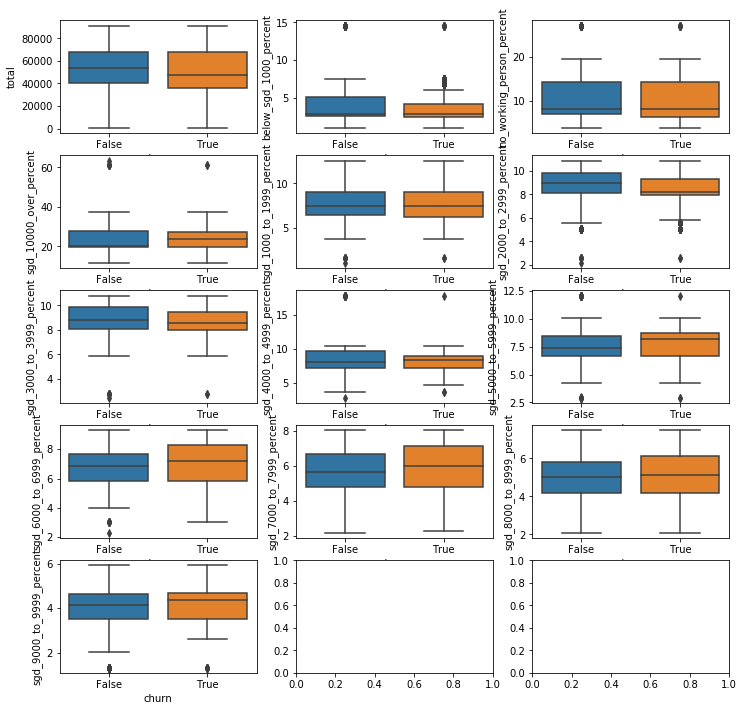

```python
nplots = len(census_cols)
ncols = 3
nrows = math.ceil(nplots/ncols)
fig, axes = plt.subplots(nrows,ncols, figsize = (12,12))
for i in range(len(census_cols)):
    sns.boxplot(x = 'churn', y = census_cols[i], data = df_train, ax = axes[i//ncols, i%ncols])
```

## cdr dataset

```python
df_cdr.head(5)
```

|  | msisdn | date | voice_incoming | voice_outgoing | sms_incoming | sms_outgoing | data_upload | data_download |
| --- | --- | --- | --- | --- | --- | --- | --- | --- |
| 0 | 6048764759382 | 2019-10-31 | 35 | 16 | 99 | 19 | 741 | 2503 |
| 1 | 1948924115781 | 2019-10-31 | 51 | 20 | 157 | 20 | 1134 | 1801 |
| 2 | 5938778408016 | 2019-10-31 | 59 | 21 | 116 | 127 | 742 | 3068 |
| 3 | 975351393328 | 2019-10-31 | 50 | 29 | 135 | 42 | 1292 | 1493 |
| 4 | 1587148418583 | 2019-10-31 | 34 | 22 | 135 | 91 | 747 | 2191 |

```python
df_cdr.shape
```

```
(90000, 8)
```

```python
df_cdr.date.value_counts()
```

```
2020-03-31    15000
2020-01-31    15000
2020-02-29    15000
2019-11-30    15000
2019-10-31    15000
2019-12-31    15000
Name: date, dtype: int64
```

```python
df_cdr = df_cdr.set_index(['msisdn','date']).unstack()
```

```python
df_cdr.columns = ['_'.join(col) for col in df_cdr.columns.values]
```

```python
df_cdr.shape
```

```
(15000, 36)
```

```python
df_train = df_train.join(df_cdr, how = 'left')
```

```python
df_train.shape
```

```
(15000, 62)
```